# Ford Go Bike Data Analysis

## by Mohit Sindhani

## Investigation Overview

> We try to explore dataset with records of Ford Go Bike Trip Data

## Dataset Overview

> There are 183412 records in the dataset with 16 columns/features We will focus on what time, demand is high. type and gender of customers who use the service

## Bike Trip Duration in seconds

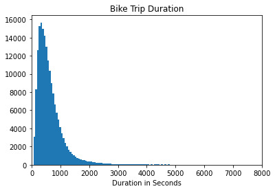

```python
#Plotting of the average trip duration
bin1 = np.arange(0, df['duration_sec'].max() + 100 , 60)
plt.hist(data = df , x = 'duration_sec' , bins = bin1)
plt.xlim(0,8000)
plt.title('Bike Trip Duration')
plt.xlabel('Duration in Seconds');
```

## Brike Trip subsciber vs customer

> Nearly 8 times more subscribers than customers

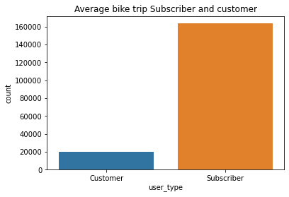

```python
sns.countplot(data=df,x='user_type')
plt.title('Average bike trip Subscriber and customer');
```

## Average Rides by Weekdays

Clearly shows that surge was there during the week esp on Tuesday, Wednesday and Thursday

Also a clear drop is seen on Weekends - Saturday and Sunday

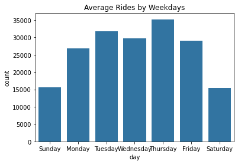

```python
order = ["Sunday", "Monday", "Tuesday", "Wednesday", "Thursday", "Friday", "Saturday"]
df['date'] = pd.DatetimeIndex(df['start_time']).date
df['day'] = pd.DatetimeIndex(df['date']).day_name()
sns.countplot(data=df,x='day', color=sns.color_palette()[0],order=order)
plt.title('Average Rides by Weekdays');
```

## Weekly Usage by User type

This chart trends shows distinction between customers and subscribers.

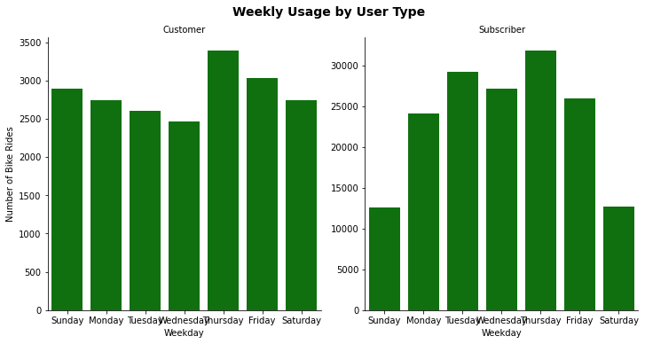

```python
order = ["Sunday", "Monday", "Tuesday", "Wednesday", "Thursday", "Friday", "Saturday"]
pl = sns.catplot(data=df, x='day', col="user_type", kind='count', sharey = False,
            color = 'green', order = order)
pl.set_axis_labels("Weekday", "Number of Bike Rides")
pl.set_titles("{col_name}")
pl.fig.suptitle('Weekly Usage by User Type', y=1.03, fontsize=14, fontweight='semibold');
```

## Bike Rides by Gender

Males in both the user types use the service more than the female gender

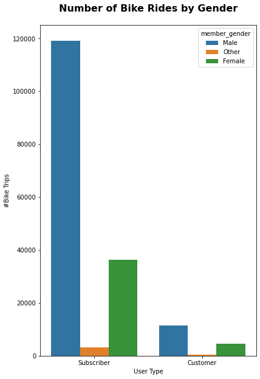

```python
plt.figure(figsize = [14, 10])

# code for the bar chart
plt.subplot(1, 2, 1)

pl = sns.countplot(data=df, x="user_type", hue="member_gender", order=df['user_type'].value_counts().index)
pl.set_xlabel('User Type')
pl.set_ylabel('#Bike Trips')
pl.set_title('Number of Bike Rides by Gender', y=1.03, fontsize=16, fontweight='semibold');
```

## Weekly Bike Trends by user type and gender

For Customer, the trend is similar across the week for both the genders

For Subscriber, the bike usage certainly increases during the week and drops during the weekends for both Male and Female

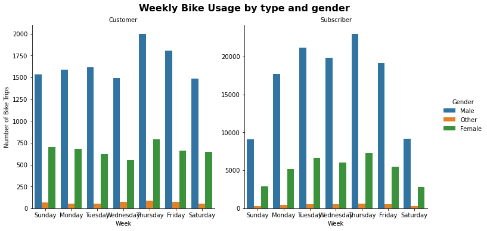

```python
order = ["Sunday", "Monday", "Tuesday", "Wednesday", "Thursday", "Friday", "Saturday"]
pl = sns.catplot(data=df, x='day', col="user_type", hue="member_gender", kind='count', sharey = False,order=order)
pl.set_axis_labels("Week", "Number of Bike Trips")
pl._legend.set_title('Gender')
pl.set_titles("{col_name}")
pl.fig.suptitle('Weekly Bike Usage by type and gender', y=1.03, fontsize=16, fontweight='semibold');
```